# Universidad Nacional de Córdoba Facultad de Ciencias Sociales Desigualdades: acceso a derechos en la ciudad de Córdoba desde una perspectiva interseccional

Resultados descriptivos de la etapa cuantitativa

# Introducción

El trabajo de investigación cuyos primero resultados se presentan a continuación se desarrolla en el marco de la convocatoria SECYT / SPU en el Área Desigualdades y Acceso a Derechos. Bajo la dirección de la Prof. María Inés Peralta, integra a los equipos de trece proyectos de investigación de la Facultad de Ciencias Sociales que abordan desde diferentes temas y perspectivas algunas de las dimensiones que configuran múltiples desigualdades, junto a un conjunto de investigadores que realizan aportes específicos en materia teórico metodológica en diferentes momentos del proceso de investigación.  
El proyecto se enfoca a la interrelación entre desigualdades y acceso a derechos desde una perspectiva interseccional. En ella nos preguntamos por el acceso efectivo a derechos de la población de la ciudad de Córdoba -específicamente en el ámbito de la salud, la educación, el trabajo, la conectividad y la información pública-, y por las acciones que lxs actores despliegan para hacer frente a los obstáculos y exclusiones en el acceso a esos derechos.

El logro de estos objetivos requiere un enfoque que integre las perspectivas cuantitativas y cualitativas. Para este trabajo se decidió un proceso secuencial con un relevamiento probabilístico de hogares de la ciudad de Córdoba como primera etapa, seguido de entrevistas en profundidad a personas pertenecientes a diferentes categorías identificadas en la etapa cuantitativa. Dos elementos forman parte de la estrategia metodológica de la primera etapa: el cuestionario y la muestra.

## El cuestionario

Para el diseño del instrumento se consideró necesario caracterizar los hogares en términos de su composición, por géneros, edad de sus integrantes, sector social de referencia, situación laboral, nivel de instrucción, cobertura de salud y condiciones de conectividad. Para ello, se elaboro inicialmente una matriz con los variables vinculadas a los conceptos que pretendía abordar en este etapa: accesibilidad a prestaciones bienes y servicios, barreras para el acceso a esas prestaciones, valoraciones en torno al impacto de la pandemia sobre el acceso a esos derechos. Se desarrollaron estas dimensiones para cada uno de los campos propuestos (trabajo, salud, educación y acceso a la información pública). A partir de esta matriz, se desarrolló un trabajo de operacionalización en el que cada uno de los equipos aportó indicadores para sus temas de referencia. Luego, la coordinación sistematizó esos aportes para el diseño del cuestionario, que se adjunta en el anexo.

## La muestra

La selección de los hogares a encuestar se realizó de manera probabilística en dos etapas. En primer lugar se definieron cinco estratos para clasificar los barrios de la ciudad, con el requisito que las categorías fueran similares en la composición socioeconómica de los hogares. Para ello, se usaron tres criterios: el porcentaje de hogares con algunas de las NBI que detectó en censo 2010, la información provista por el RENABAP y el conocimiento del terreno de parte de los equipos de investigación que integran en proyecto.

Con estos criterios, la ciudad fue clasificada en cinco zonas geográficas en las que las características socioeconómicas predominantes de los hogares son similares. Esta caracterización no anula la diversidad de las características socioeconómicas de los hogares que pueden escapar a la caracterización del barrio al cual pertenecen, sino que hace referencia a que la generalidad de los hogares que componen el barrio tienen dichas características. Así, en este estudio se analiza la diferencia en el acceso a derechos por parte de grupos ubicados en diferentes zonas residenciales de la ciudad de Córdoba, considerando su jerarquización socioeconómica.  
Una vez definidos los estratos, se seleccionaron aleatoriamente cinco barrios de cada uno y en cada uno de ellos se eligieron, también aleatoriamente, las coordenadas de un punto en el que se inició un recorrido sistemático preestablecido, por las viviendas del barrio. El número de viviendas salteado en la etapa sistemática del muestreo fue fijado con anterioridad, según el tamaño del barrios. En cada vivienda seleccionada se encuestó a la totalidad de hogares residentes.  
La Figura 1 muestra la clasificación de barrios resultante del proceso detallado anteriormente.

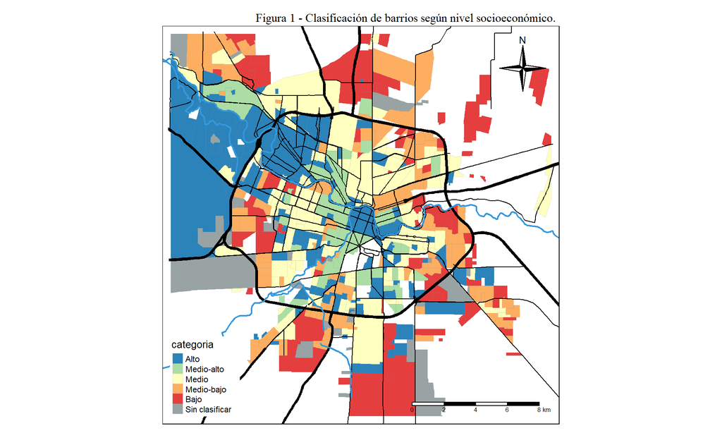

## El trabajo de campo

La administración del cuestionario fue realizada por un equipo conformado por docentes, graduados y estudiantes de la facultad que integran los equipos de investigación. El trabajo se organizó con cinco supervisores, cada uno de ellos a cargo de cinco puntos muestrales. Luego, un equipo de trece encuestadores aplicó la encuesta entre el 19 y el 27 de marzo de 2021. La encuesta se realizó de dos maneras: al momento de contactar de manera presencial un referente del hogar muestreado, se aplicó un cuestionario breve con la caracterización general de ese hogar, luego se consultaba la preferencia de esa persona para contestar el resto de la encuesta de manera presencial o telefónica. Se obtuvieron respuesta de 615 hogares

El presente informe ofrece una descripción de los hogares que fueron encuestados, el modo en que la pandemia impactó en el trabajo, la salud y la educación, y las estrategias a las que los hogares apelaron para paliar sus efectos. Cada aspecto es observado según el nivel socoeconómico del área en que los hogares están ubicados.

# Descripción general

## Las personas que respondieron a la encuesta

La información que produce la presente encuesta se refiere a los hogares como unidad de observación, en razón de ello, la persona que proveyó los datos no fue seleccionada al azar sino en base a su disponibilidad. Quienes respondieron fueron mayoritariamente mujeres (68%, según tabla 1) mayores de 18 años, con una edad promedio de 48 años. Su lugar de origen se concentra en la ciudad de Córdoba (72%), otras provincias (15%) y otras localidades de la provincia de Córdoba (11%, tabla 3).

Composición por género según NSE (porcentajes por NSE)

|  | Alto | Medio alto | Medio | Medio Bajo | Bajo | Sum |
| --- | --- | --- | --- | --- | --- | --- |
| Mujer | 62.8 | 68.4 | 57 | 72.4 | 77.4 | 67.8 |
| Otros | 0.0 | 0.9 | 0 | 0.8 | 0.0 | 0.3 |
| Varón | 37.2 | 30.8 | 43 | 26.8 | 22.6 | 31.9 |
| Sum | 100.0 | 100.0 | 100 | 100.0 | 100.0 | 100.0 |

Composición por género según NSE (absolutos)

|  | Alto | Medio alto | Medio | Medio Bajo | Bajo | Sum |
| --- | --- | --- | --- | --- | --- | --- |
| Mujer | 76 | 80 | 69 | 89 | 103 | 417 |
| Otros | 0 | 1 | 0 | 1 | 0 | 2 |
| Varón | 45 | 36 | 52 | 33 | 30 | 196 |
| Sum | 121 | 117 | 121 | 123 | 133 | 615 |

Lugar de nacimiento (porcentajes según NSE)

|  | Alto | Medio alto | Medio | Medio Bajo | Bajo | Sum |
| --- | --- | --- | --- | --- | --- | --- |
| Ciudad de Córdoba | 67.8 | 67.5 | 74.4 | 67.5 | 82.7 | 72.2 |
| En otro país no limítrofe | 0.8 | 0.0 | 0.8 | 4.1 | 0.0 | 1.1 |
| En países limítrofes | 0.8 | 0.9 | 0.0 | 0.8 | 0.0 | 0.5 |
| Otra localidad de Córdoba | 5.8 | 12.8 | 13.2 | 17.9 | 6.0 | 11.1 |
| Otra provincia | 24.8 | 18.8 | 11.6 | 9.8 | 11.3 | 15.1 |
| Sum | 100.0 | 100.0 | 100.0 | 100.0 | 100.0 | 100.0 |

Lugar de nacimiento según NSE (absolutos)

|  | Alto | Medio alto | Medio | Medio Bajo | Bajo | Sum |
| --- | --- | --- | --- | --- | --- | --- |
| Ciudad de Córdoba | 82 | 79 | 90 | 83 | 110 | 444 |
| En otro país no limítrofe | 1 | 0 | 1 | 5 | 0 | 7 |
| En países limítrofes | 1 | 1 | 0 | 1 | 0 | 3 |
| Otra localidad de Córdoba | 7 | 15 | 16 | 22 | 8 | 68 |
| Otra provincia | 30 | 22 | 14 | 12 | 15 | 93 |
| Sum | 121 | 117 | 121 | 123 | 133 | 615 |

## Composición y características de los hogares

Composición de los hogares por género y grupos de edades convivientes

|  | sin menores, sin mayores | sin menores, con mayores | con menores, sin mayores | con menores, con mayores | Sum |
| --- | --- | --- | --- | --- | --- |
| Igual cantidad de varones y mujeres | 37.9 | 48.9 | 21.4 | 14.3 | 34.0 |
| Mayoría de mujeres | 28.0 | 30.1 | 43.9 | 57.1 | 36.5 |
| Mayoría de varones | 34.1 | 21.0 | 34.7 | 28.6 | 29.5 |
| Sum | 100.0 | 100.0 | 100.0 | 100.0 | 100.0 |

Composición de los hogares por género y grupos de edades convivientes (absolutos)

|  | sin menores, sin mayores | sin menores, con mayores | con menores, sin mayores | con menores, con mayores | Sum |
| --- | --- | --- | --- | --- | --- |
| Igual cantidad de varones y mujeres | 50 | 91 | 42 | 6 | 189 |
| Mayoría de mujeres | 37 | 56 | 86 | 24 | 203 |
| Mayoría de varones | 45 | 39 | 68 | 12 | 164 |
| Sum | 132 | 186 | 196 | 42 | 556 |

Media y mediana de la cantidad de integrantes del hogar según NSE

| nse | media | mediana |
| --- | --- | --- |
| Alto | 3.18 | 3 |
| Medio alto | 3.15 | 3 |
| Medio | 3.51 | 3 |
| Medio Bajo | 3.89 | 4 |
| Bajo | 4.28 | 4 |

Cantidad de menores de 14 años en el hogar (porcentajes por NSE)

|  | Alto | Medio alto | Medio | Medio Bajo | Bajo | Sum |
| --- | --- | --- | --- | --- | --- | --- |
| 0 | 66.1 | 70.1 | 66.9 | 52.8 | 41.4 | 59.0 |
| 1 | 13.2 | 13.7 | 20.7 | 20.3 | 22.6 | 18.2 |
| 2 | 14.9 | 10.3 | 8.3 | 14.6 | 22.6 | 14.3 |
| 3 | 5.0 | 4.3 | 3.3 | 9.8 | 7.5 | 6.0 |
| 4 | 0.8 | 1.7 | 0.0 | 0.8 | 3.0 | 1.3 |
| 5 | 0.0 | 0.0 | 0.8 | 0.8 | 3.0 | 1.0 |
| 8 | 0.0 | 0.0 | 0.0 | 0.8 | 0.0 | 0.2 |
| Sum | 100.0 | 100.0 | 100.0 | 100.0 | 100.0 | 100.0 |

Cantidad de menores de 14 años en el hogar según NSE (absolutos)

|  | Alto | Medio alto | Medio | Medio Bajo | Bajo | Sum |
| --- | --- | --- | --- | --- | --- | --- |
| 0 | 80 | 82 | 81 | 65 | 55 | 363 |
| 1 | 16 | 16 | 25 | 25 | 30 | 112 |
| 2 | 18 | 12 | 10 | 18 | 30 | 88 |
| 3 | 6 | 5 | 4 | 12 | 10 | 37 |
| 4 | 1 | 2 | 0 | 1 | 4 | 8 |
| 5 | 0 | 0 | 1 | 1 | 4 | 6 |
| 8 | 0 | 0 | 0 | 1 | 0 | 1 |
| Sum | 121 | 117 | 121 | 123 | 133 | 615 |

Composición de los hogares por tamaño y grupos de edades (porcentajes por NSE)

|  | Alto | Medio alto | Medio | Medio Bajo | Bajo | Sum |
| --- | --- | --- | --- | --- | --- | --- |
| menos de 5, sin menores, sin mayores | 26.7 | 26.1 | 26.4 | 12.2 | 23.7 | 23.0 |
| menos de 5, sin menores, con mayores | 32.5 | 36.5 | 35.5 | 35.8 | 11.5 | 30.0 |
| menos de 5, con menores, sin mayores | 20.0 | 13.9 | 11.6 | 14.6 | 23.7 | 16.9 |
| menos de 5, con menores, con mayores | 1.7 | 0.9 | 5.0 | 2.4 | 2.3 | 2.5 |
| 5 o más, sin menores, sin mayores | 3.3 | 2.6 | 4.1 | 2.4 | 3.1 | 3.1 |
| 5 o más, sin menores, con mayores | 3.3 | 4.3 | 0.8 | 2.4 | 3.1 | 2.8 |
| 5 o más, con menores, sin mayores | 10.8 | 13.9 | 10.7 | 20.3 | 28.2 | 17.0 |
| 5 o más, con menores, con mayores | 1.7 | 1.7 | 5.8 | 9.8 | 4.6 | 4.8 |
| Sum | 100.0 | 100.0 | 100.0 | 100.0 | 100.0 | 100.0 |

Composición de los hogares por tamaño y grupos de edades según NSE (absolutos)

|  | Alto | Medio alto | Medio | Medio Bajo | Bajo | Sum |
| --- | --- | --- | --- | --- | --- | --- |
| menos de 5, sin menores, sin mayores | 32 | 30 | 32 | 15 | 31 | 140 |
| menos de 5, sin menores, con mayores | 39 | 42 | 43 | 44 | 15 | 183 |
| menos de 5, con menores, sin mayores | 24 | 16 | 14 | 18 | 31 | 103 |
| menos de 5, con menores, con mayores | 2 | 1 | 6 | 3 | 3 | 15 |
| 5 o más, sin menores, sin mayores | 4 | 3 | 5 | 3 | 4 | 19 |
| 5 o más, sin menores, con mayores | 4 | 5 | 1 | 3 | 4 | 17 |
| 5 o más, con menores, sin mayores | 13 | 16 | 13 | 25 | 37 | 104 |
| 5 o más, con menores, con mayores | 2 | 2 | 7 | 12 | 6 | 29 |
| Sum | 120 | 115 | 121 | 123 | 131 | 610 |

Composición de los hogares por grupos de edades convivientes (porcentajes por NSE)

|  | Alto | Medio alto | Medio | Medio Bajo | Bajo | Sum |
| --- | --- | --- | --- | --- | --- | --- |
| sin menores, sin mayores | 29.8 | 28.2 | 30.6 | 14.6 | 26.3 | 25.9 |
| sin menores, con mayores | 36.4 | 41.0 | 36.4 | 38.2 | 15.0 | 33.0 |
| con menores, sin mayores | 30.6 | 28.2 | 22.3 | 35.0 | 51.1 | 33.8 |
| con menores, con mayores | 3.3 | 2.6 | 10.7 | 12.2 | 7.5 | 7.3 |
| Sum | 100.0 | 100.0 | 100.0 | 100.0 | 100.0 | 100.0 |

Composición de los hogares por grupos de edades convivientes según NSE (absolutos)

|  | Alto | Medio alto | Medio | Medio Bajo | Bajo | Sum |
| --- | --- | --- | --- | --- | --- | --- |
| sin menores, sin mayores | 36 | 33 | 37 | 18 | 35 | 159 |
| sin menores, con mayores | 44 | 48 | 44 | 47 | 20 | 203 |
| con menores, sin mayores | 37 | 33 | 27 | 43 | 68 | 208 |
| con menores, con mayores | 4 | 3 | 13 | 15 | 10 | 45 |
| Sum | 121 | 117 | 121 | 123 | 133 | 615 |

Hogares con hacinamiento crítico (porcentajes según NSE)

|  | Alto | Medio alto | Medio | Medio Bajo | Bajo | Sum |
| --- | --- | --- | --- | --- | --- | --- |
| más de tres personas por cuarto | 0.8 | 1.7 | 0 | 3.3 | 10.8 | 3.3 |
| tres personas o menos por cuarto | 99.2 | 98.3 | 100 | 96.7 | 89.2 | 96.7 |
| Sum | 100.0 | 100.0 | 100 | 100.0 | 100.0 | 100.0 |

Hogares con hacinamiento crítico (absolutos según NSE)

|  | Alto | Medio alto | Medio | Medio Bajo | Bajo | Sum |
| --- | --- | --- | --- | --- | --- | --- |
| más de tres personas por cuarto | 1 | 2 | 0 | 4 | 13 | 20 |
| tres personas o menos por cuarto | 119 | 113 | 121 | 118 | 107 | 578 |
| Sum | 120 | 115 | 121 | 122 | 120 | 598 |

Integrantes cursando jardín de infantes (porcentajes según NSE)

|  | Alto | Medio alto | Medio | Medio Bajo | Bajo | Sum |
| --- | --- | --- | --- | --- | --- | --- |
| No | 35 | 82.5 | 76.9 | 57.6 | 75 | 71 |
| Sí | 65 | 17.5 | 23.1 | 42.4 | 25 | 29 |
| Sum | 100 | 100.0 | 100.0 | 100.0 | 100 | 100 |

Integrantes cursando jardín de infantes según NSE (absolutos)

|  | Alto | Medio alto | Medio | Medio Bajo | Bajo | Sum |
| --- | --- | --- | --- | --- | --- | --- |
| No | 7 | 52 | 30 | 19 | 39 | 147 |
| Sí | 13 | 11 | 9 | 14 | 13 | 60 |
| Sum | 20 | 63 | 39 | 33 | 52 | 207 |

Integrantes cursando primario (porcentajes según NSE)

|  | Alto | Medio alto | Medio | Medio Bajo | Bajo | Sum |
| --- | --- | --- | --- | --- | --- | --- |
| No | 21.2 | 65.8 | 58 | 30.4 | 27.5 | 42.1 |
| Sí | 78.8 | 34.2 | 42 | 69.6 | 72.5 | 57.9 |
| Sum | 100.0 | 100.0 | 100 | 100.0 | 100.0 | 100.0 |

Integrantes cursando primario según NSE (absolutos)

|  | Alto | Medio alto | Medio | Medio Bajo | Bajo | Sum |
| --- | --- | --- | --- | --- | --- | --- |
| No | 7 | 48 | 29 | 17 | 22 | 123 |
| Sí | 26 | 25 | 21 | 39 | 58 | 169 |
| Sum | 33 | 73 | 50 | 56 | 80 | 292 |

Integrantes cursando secundario (porcentajes según NSE)

|  | Alto | Medio alto | Medio | Medio Bajo | Bajo | Sum |
| --- | --- | --- | --- | --- | --- | --- |
| No | 14.3 | 69.3 | 49 | 19.2 | 23.6 | 37.9 |
| Sí | 85.7 | 30.7 | 51 | 80.8 | 76.4 | 62.1 |
| Sum | 100.0 | 100.0 | 100 | 100.0 | 100.0 | 100.0 |

Integrantes cursando secundario según NSE (absolutos)

|  | Alto | Medio alto | Medio | Medio Bajo | Bajo | Sum |
| --- | --- | --- | --- | --- | --- | --- |
| No | 4 | 52 | 24 | 10 | 21 | 111 |
| Sí | 24 | 23 | 25 | 42 | 68 | 182 |
| Sum | 28 | 75 | 49 | 52 | 89 | 293 |

Integrantes cursando universitario o terciario (porcentajes según NSE)

|  | Alto | Medio alto | Medio | Medio Bajo | Bajo | Sum |
| --- | --- | --- | --- | --- | --- | --- |
| No | 10.8 | 59.8 | 34.5 | 55.6 | 67.9 | 48.7 |
| Sí | 89.2 | 40.2 | 65.5 | 44.4 | 32.1 | 51.3 |
| Sum | 100.0 | 100.0 | 100.0 | 100.0 | 100.0 | 100.0 |

Integrantes cursando universitario o terciario según NSE (absolutos)

|  | Alto | Medio alto | Medio | Medio Bajo | Bajo | Sum |
| --- | --- | --- | --- | --- | --- | --- |
| No | 4 | 49 | 19 | 20 | 36 | 128 |
| Sí | 33 | 33 | 36 | 16 | 17 | 135 |
| Sum | 37 | 82 | 55 | 36 | 53 | 263 |